# John Zeiders (jzeiders) - Project 3 Submission

# Section 1: Sentiment Classification Model Technical Details

## Implementation Overview

The implementation uses a Logistic Regression model with carefully tuned hyperparameters for sentiment classification. Here are the key technical aspects:

### Data Preprocessing

- Features are preprocessed by dropping the 'id' and 'review' columns, retaining only the numerical feature columns
- The target variable 'sentiment' is separated from the features
- Data is loaded using Polars for efficient memory management and fast I/O operations

### Model Architecture

- Algorithm: Logistic Regression
- Solver: 'liblinear' (efficient for smaller datasets)
- Hyperparameters:
  - C=10 (inverse of regularization strength)
  - max_iter=1000 (maximum iterations for convergence)
  - random_state=42 (for reproducibility)

### Training Process

- The model is trained independently on 5 different data splits
- Each split's training process is isolated to ensure proper validation
- Grid search capability is included but not used in the final results (configured for C values: [0.01, 0.1, 1, 10, 100])

### Performance Metrics

Here's a detailed breakdown of the performance across all splits:

| Split | AUC Score | Training Time (s) | Inference Time (s) |
| --- | --- | --- | --- |
| 1 | 0.987113 | 6.27 | 0.10 |
| 2 | 0.986805 | 6.76 | 0.09 |
| 3 | 0.986430 | 7.51 | 0.17 |
| 4 | 0.986983 | 6.17 | 0.07 |
| 5 | 0.986284 | 7.77 | 0.10 |

### System Specifications

- Hardware: MacBook Pro with Apple M2 Max
- Memory: 32GB
- Total Training Time: 34.48 seconds
- Average Training Time per Split: 6.90 seconds
- Total Inference Time: 0.52 seconds
- Average Inference Time per Split: 0.10 seconds

# Section 2: Interpretability Analysis

I implemented LIME (Local Interpretable Model-agnostic Explanations) to analyze how our sentiment classification model makes its predictions. Here's a detailed breakdown of the approach:

## How LIME Works in This Context

1. For each review, LIME creates perturbed versions by randomly removing words
2. The model makes predictions on these perturbed samples
3. LIME fits a linear model locally around the prediction to understand which words contributed most significantly
4. The result shows which words pushed the prediction toward positive or negative sentiment

## Advantages of Using LIME

1. Model-Agnostic: Works seamlessly with our classifier without requiring modifications
2. Intuitive Output: Provides word-level importance scores that are easy to interpret
3. Local Fidelity: Accurately explains individual predictions
4. Visual Clarity: Color-coded text highlights make it easy to see which parts of the review influenced the prediction

## Limitations and Challenges

1. Word Independence: LIME assumes words are independent, which isn't always true in natural language (e.g., "not good" vs "good")
2. Computational Cost: Generating explanations is relatively slow due to needed multiple model predictions
3. Stability: Different runs can produce slightly different explanations due to random sampling
4. Context Loss: May miss broader contextual patterns or subtle sentiment indicators

## Results Analysis

The visualizations (shown in combined_analysis.png) demonstrate how the model weighs different parts of each review:

- Green highlighting indicates words contributing to positive sentiment
- Red highlighting indicates words contributing to negative sentiment
- The intensity of the color represents the strength of the contribution
- Words with minimal impact on the prediction are shown in light gray

This analysis helps validate that our model is focusing on appropriate sentiment indicators and provides transparency into its decision-making process.

[figure not shown]

```python
import os
import json
from pathlib import Path
from typing import Dict, Optional, Union
import numpy as np
import pandas as pd
import polars as pl
import matplotlib.pyplot as plt
from sklearn.linear_model import LinearRegression, LogisticRegression
from sklearn.model_selection import train_test_split
from sklearn.metrics import mean_squared_error
import joblib
from transformers import BertTokenizer, BertModel
import torch
import requests
import tempfile
from lime.lime_text import LimeTextExplainer
import hashlib
from tqdm import tqdm


# -----------------------------
# Section 1: Setting Up
# -----------------------------

# Constants
BERT_DIM = 768
OPENAI_DIM = 1536
TRANSFORMATION_MATRIX_FILE = 'bert_to_openai_W.pkl'
BINARY_CLASSIFIER_FILE = 'https://raw.githubusercontent.com/jzeiders/GraduateML/main/src/Project3/submission/xgb_model_splitsplit_1.joblib'

torch.manual_seed(42)

# -----------------------------
# Section 2: Loading and Preparing Data
# -----------------------------

def load_data(file_path):
    """
    Loads paired embeddings data from a CSV file.

    The CSV file is expected to have the following columns:
    - 'text': The original text data.
    - 'openai_embedding': Stringified list of OpenAI embeddings (length 1536).

    BERT embeddings will be computed on the fly.

    Parameters:
    - file_path: Path to the CSV file.

    Returns:
    - DataFrame with 'text' and 'openai_embedding' columns.
    """
    df = pd.read_csv(file_path)
    # Convert the stringified embeddings to actual numpy arrays
    df['openai_embedding'] = df['openai_embedding'].apply(lambda x: np.fromstring(x.strip('[]'), sep=','))
    return df

# -----------------------------
# Section 3: Computing BERT Embeddings
# -----------------------------
class CacheManager:
    def __init__(self, cache_dir: str):
        """
        Manages the file-backed cache for embeddings.

        Parameters:
        - cache_dir: Directory to store cache files
        """
        self.cache_dir = Path(cache_dir)
        self.metadata_file = self.cache_dir / "metadata.json"
        self.embeddings_dir = self.cache_dir / "embeddings"

        # Create cache directories if they don't exist
        self.cache_dir.mkdir(exist_ok=True)
        self.embeddings_dir.mkdir(exist_ok=True)

        # Load or initialize metadata
        self.metadata = self._load_metadata()

    def _load_metadata(self) -> Dict:
        """Load cache metadata from disk or initialize if not exists."""
        if self.metadata_file.exists():
            with open(self.metadata_file, 'r') as f:
                return json.load(f)
        return {}

    def _save_metadata(self):
        """Save cache metadata to disk."""
        with open(self.metadata_file, 'w') as f:
            json.dump(self.metadata, f)

    def _get_hash(self, text: str) -> str:
        """Generate a hash for the input text."""
        return hashlib.md5(text.encode()).hexdigest()

    def get(self, text: str) -> Optional[np.ndarray]:
        """
        Retrieve embedding from cache if it exists.

        Returns None if not found.
        """
        text_hash = self._get_hash(text)
        if text_hash not in self.metadata:
            return None

        embedding_path = self.embeddings_dir / f"{text_hash}.npy"
        if not embedding_path.exists():
            return None

        return np.load(embedding_path)

    def put(self, text: str, embedding: np.ndarray):
        """Store embedding in cache."""
        text_hash = self._get_hash(text)

        # Save embedding
        embedding_path = self.embeddings_dir / f"{text_hash}.npy"
        np.save(embedding_path, embedding)

        # Update metadata
        self.metadata[text_hash] = {
            'text': text,
            'shape': embedding.shape
        }
        self._save_metadata()

    def clear(self):
        """Clear all cache contents."""
        # Remove all embedding files
        for f in self.embeddings_dir.glob("*.npy"):
            f.unlink()

        # Clear metadata
        self.metadata = {}
        self._save_metadata()

class BERTEmbedder:
    def __init__(self, model_name='bert-base-uncased', cache_dir='/Users/jzeiders/Documents/Code/Learnings/GraduateML/src/Project3/bert_cache'):
        """
        BERT embedder with file-backed caching.

        Parameters:
        - model_name: Name of the BERT model to use
        - cache_dir: Directory to store embedding cache
        """
        self.tokenizer = BertTokenizer.from_pretrained(model_name)
        self.model = BertModel.from_pretrained(model_name)
        self.model.eval()
        self.cache = CacheManager(cache_dir)

    def get_embedding(self, text: str) -> np.ndarray:
        """
        Get BERT embedding for text, using cache if available.

        Parameters:
        - text: Input text string

        Returns:
        - Numpy array of shape (768,)
        """
        # Check cache first
        cached_embedding = self.cache.get(text)
        if cached_embedding is not None:
            return cached_embedding

        # Compute embedding if not in cache
        with torch.no_grad():
            inputs = self.tokenizer(text, return_tensors='pt', truncation=True,
                                  padding=True, max_length=512)
            outputs = self.model(**inputs)
            cls_embedding = outputs.last_hidden_state[:, 0, :].squeeze().numpy()

        assert cls_embedding.shape == (BERT_DIM,), \
            f"Expected shape: {(BERT_DIM,)}, Got: {cls_embedding.shape}"

        # Store in cache
        self.cache.put(text, cls_embedding)

        return cls_embedding

    def clear_cache(self):
        """Clear the embedding cache."""
        self.cache.clear()

def compute_bert_embeddings(df: pl.DataFrame, embedder: BERTEmbedder, batch_size=32):
    """
    Computes BERT embeddings for all texts in the DataFrame.
    """
    bert_embeddings = []
    for text in tqdm(df['review'], total=len(df), desc="Computing BERT embeddings"):
        embedding = embedder.get_embedding(text)
        bert_embeddings.append(embedding)
```

```python
    embeddings = np.vstack(bert_embeddings)
    assert embeddings.shape == (len(df), BERT_DIM)
    return embeddings

# -----------------------------
# Section 4: Fitting the Linear Regression Model
# -----------------------------

def fit_linear_regression(X_train, Y_train):
    """
    Fits a linear regression model to map BERT embeddings to OpenAI embeddings.

    Parameters:
    - X_train: Training BERT embeddings (n_samples, 768)
    - Y_train: Training OpenAI embeddings (n_samples, 1536)

    Returns:
    - Trained LinearRegression model
    """
    linear_reg = LinearRegression()
    print("Fitting the linear regression model...")
    linear_reg.fit(X_train, Y_train)
    print("Model fitting complete.")
    return linear_reg

# -----------------------------
# Section 5: Evaluating the Transformation
# -----------------------------

def evaluate_transformation(model, X_test, Y_test):
    """
    Evaluates the linear regression model using Mean Squared Error.

    Parameters:
    - model: Trained LinearRegression model
    - X_test: Testing BERT embeddings (n_samples, 768)
    - Y_test: Testing OpenAI embeddings (n_samples, 1536)

    Returns:
    - Mean Squared Error
    """
    Y_pred = model.predict(X_test)
    mse = mean_squared_error(Y_test, Y_pred)
    print(f"Mean Squared Error on Test Set: {mse:.4f}")
    return mse

# -----------------------------
# Section 6: Saving and Loading Models
# -----------------------------

def save_transformation_matrix(model, file_path):
    """
    Saves the transformation matrix W to a file.

    Parameters:
    - model: Trained LinearRegression model
    - file_path: Path to save the transformation matrix
    """
    W = model.coef_.T  # Shape: (768, 1536)
    joblib.dump(W, file_path)
    print(f"Transformation matrix W saved as '{file_path}'.")

def load_transformation_matrix(file_path):
    """
    Loads the transformation matrix W from a file.

    Parameters:
    - file_path: Path to the transformation matrix file.

    Returns:
    - Numpy array of shape (768, 1536)
    """
    W = joblib.load(file_path)
    print(f"Transformation matrix W loaded from '{file_path}'.")
    return W

def load_binary_classifier(file_path: str) -> LogisticRegression:
    """
    Loads the pre-trained binary classification model.

    Parameters:
    - file_path: Path to the binary classifier file.

    Returns:
    - Loaded binary classification model
    """
import requests
import joblib
import tempfile
from typing import Union
from sklearn.linear_model import LogisticRegression
from urllib.parse import urlparse

def load_binary_classifier(file_path: Union[str, bytes]) -> LogisticRegression:
    """
    Loads the pre-trained binary classification model from either a local path or remote URL.

    Parameters:
    - file_path: Path to the binary classifier file. Can be either:
                - Local file path (str)
                - Remote URL (str)
                - Bytes object containing the model data

    Returns:
    - Loaded binary classification model

    Raises:
    - ValueError: If the URL is invalid or file cannot be downloaded
    - Exception: If model loading fails
    """
    # Check if input is already bytes
    if isinstance(file_path, bytes):
        with tempfile.NamedTemporaryFile() as tmp_file:
            tmp_file.write(file_path)
            tmp_file.flush()
            return joblib.load(tmp_file.name)

    # Check if the path is a URL
    parsed = urlparse(file_path)
    if parsed.scheme in ('http', 'https'):
        try:
            # Download the file
            response = requests.get(file_path)
            response.raise_for_status()

            # Save to temporary file and load
            with tempfile.NamedTemporaryFile() as tmp_file:
                for chunk in response.iter_content(chunk_size=8192):
                    tmp_file.write(chunk)
                tmp_file.flush()
                return joblib.load(tmp_file.name)
        except Exception as e:
            raise ValueError(f"Failed to download or load binary classifier from URL: {e}")
    else:
        return joblib.load(file_path)

# -----------------------------
# Section 7: Classifying New Text Inputs
# -----------------------------

class SentimentClassifier:
    def __init__(self, bert_embedder, binary_classifier, convert_model: LinearRegression):
        self.embedder = bert_embedder
        self.convert_model = convert_model
        self.classifier = binary_classifier

    def classify_sentiment(self, text: str) -> float:
        """Classifies the sentiment of a given text."""
        bert_emb = self.embedder.get_embedding(text)
        openai_emb = self.convert_model.predict(bert_emb.reshape(1, -1))

        # Create DataFrame with numbered embedding columns
        embedding_df = pd.DataFrame(
            openai_emb,
            columns=[f"embedding_{i+1}" for i in range(openai_emb.shape[1])]
        )

        return self.classifier.predict_proba(embedding_df)[0][1]

def analyze_multiple_reviews(test_data, sentiment_classifier: SentimentClassifier):
    """
    Analyzes 5 positive and 5 negative reviews and combines their visualizations.
    """
    # Create results directory
    results_dir = os.path.join('results', 'combined_analysis')
    os.makedirs(results_dir, exist_ok=True)

    positive_indices = []
    negative_indices = []

    # Process reviews with progress bar
    pbar = tqdm(test_data['review'], desc="Finding reviews")
    for idx, review in enumerate(pbar):
        if len(positive_indices) >= 5 and len(negative_indices) >= 5:
            break

        sentiment = sentiment_classifier.classify_sentiment(review)

        if len(positive_indices) < 5 and sentiment > 0.8:
            positive_indices.append(idx)
            pbar.set_postfix({'positive': len(positive_indices), 'negative': len(negative_indices)})
        elif len(negative_indices) < 5 and sentiment < 0.2:
            negative_indices.append(idx)
            pbar.set_postfix({'positive': len(positive_indices), 'negative': len(negative_indices)})
```

```
Loading data...
```

```
Training linear regression model...
Fitting the linear regression model...
Model fitting complete.
Mean Squared Error on Test Set: 0.0010
Transformation matrix W saved as 'bert_to_openai_W.pkl'.
```

```
Generating LIME explanation for review 1
```

```
Generating LIME explanation for review 2
```

```
Generating LIME explanation for review 3
```

```
Generating LIME explanation for review 4
```

```
Generating LIME explanation for review 5
```

```
Generating LIME explanation for review 6
```

```
Generating LIME explanation for review 7
```

```
Generating LIME explanation for review 8
```

```
Generating LIME explanation for review 9
```

```
Generating LIME explanation for review 10
```

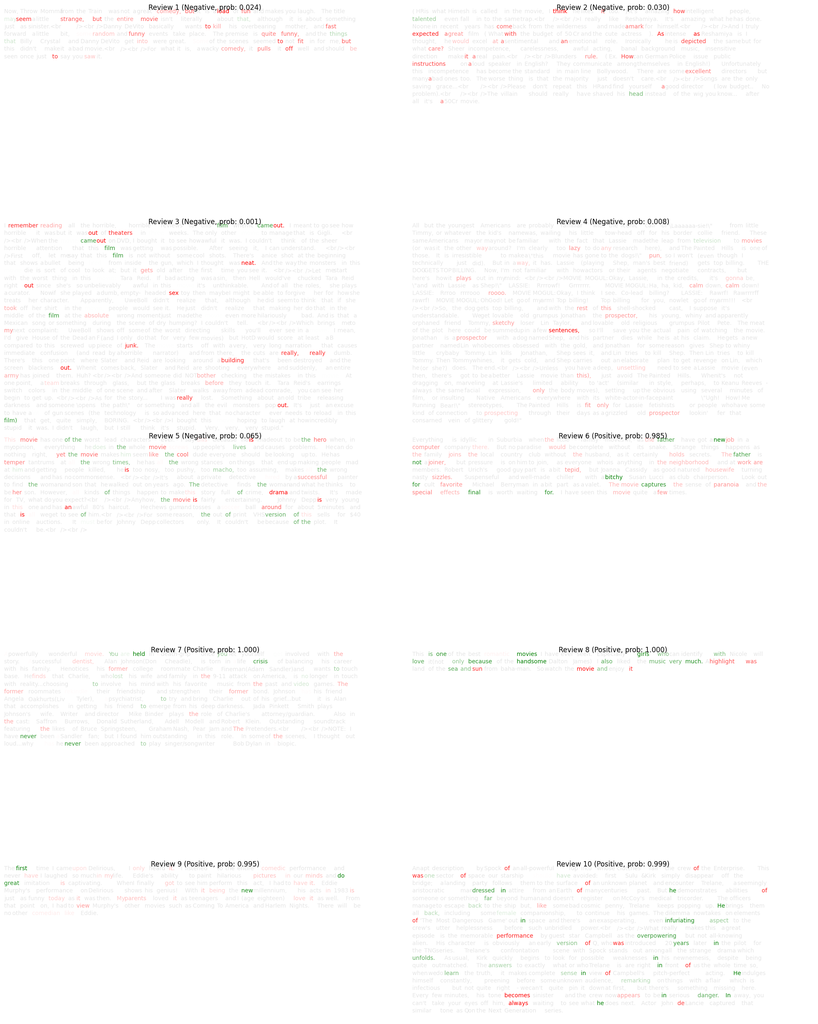

```
Combined analysis saved to: results/combined_analysis/combined_analysis.png
```

```python
    if len(positive_indices) < 5 or len(negative_indices) < 5:
        print("Warning: Could not find enough reviews of each type.")
        print(f"Found {len(positive_indices)} positive and {len(negative_indices)} negative reviews.")

    # Create figure with subplots for all reviews
    fig = plt.figure(figsize=(20, 25))

    # Process each review with progress bar
    for idx, review_idx in enumerate(tqdm(negative_indices + positive_indices, desc="Generating LIME explanations")):
        review = test_data['review'][review_idx]
        sentiment = sentiment_classifier.classify_sentiment(review)

        # Create LIME explanation
        def predictor(texts):
            probs = []
            for t in texts:
                p = sentiment_classifier.classify_sentiment(t)
                probs.append(np.array([1-p, p]))
            return np.array(probs)

        explainer = LimeTextExplainer(class_names=['negative', 'positive'])
        print(f"Generating LIME explanation for review {idx + 1}")
        exp = explainer.explain_instance(
            review,
            predictor,
            num_features=30,
            num_samples=10
        )

        # Get feature weights
        features_with_weights = exp.as_list()
        word_weights = {feature[0]: feature[1] for feature in features_with_weights}

        # Create subplot
        ax = fig.add_subplot(5, 2, idx + 1)

        # Split review into words and create colored text
        words = review.split()
        y_position = 1.0
        x_position = 0.0
        line_height = 0.05
        current_line = []
        current_line_width = 0
        max_line_width = 0.9  # Maximum width of a line

        # Normalize weights for coloring
        weights = np.array(list(word_weights.values()))
        max_abs_weight = max(abs(weights.min()), abs(weights.max())) if len(weights) > 0 else 1

        for word in words:
            clean_word = word.lower().strip('.,!?()[]{}":;')
            weight = word_weights.get(clean_word, 0)

            # Calculate word width (approximate)
            word_width = len(word) * 0.01

            # Check if we need to start a new line
            if current_line_width + word_width > max_line_width:
                y_position -= line_height
                x_position = 0.0
                current_line_width = 0
                current_line = []

            # Add word to visualization
            if clean_word in word_weights:
                color = 'green' if weight > 0 else 'red'
                alpha = min(abs(weight) / max_abs_weight, 1)
            else:
                color = 'gray'
                alpha = 0.2

            ax.text(x_position, y_position, word + ' ',
                   color=color, alpha=alpha, transform=ax.transAxes)

            x_position += word_width
            current_line_width += word_width
            current_line.append(word)

        # Set title and remove axes
        sentiment_label = "Positive" if sentiment > 0.5 else "Negative"
        ax.set_title(f"Review {idx + 1} ({sentiment_label}, prob: {sentiment:.3f})")
        ax.axis('off')

    plt.tight_layout()

    # Save the combined visualization
    output_path = os.path.join(results_dir, 'combined_analysis.png')
    plt.savefig(output_path, dpi=300, bbox_inches='tight')

    plt.show()
    plt.close()


    print(f"Combined analysis saved to: {output_path}")

# -----------------------------
# Section 8: Main Execution Flow
# -----------------------------

def main():
    # Load data
    data_dir = "/Users/jzeiders/Documents/Code/Learnings/GraduateML/src/Project3/data/split_1"
    print("Loading data...")
    train_data = pl.read_csv(os.path.join(data_dir, 'train.csv'))
    test_data = pl.read_csv(os.path.join(data_dir, 'test.csv'))

    # Use subset for training
    train_subset = train_data[:1000]

    # Initialize BERT embedder and compute embeddings
    bert_embedder = BERTEmbedder()
    bert_embeddings = compute_bert_embeddings(train_subset, bert_embedder)

    # Prepare features
    X = bert_embeddings
    Y = np.vstack(train_subset.drop(['id','sentiment', 'review']).to_numpy())

    # Train model
    X_train, X_test, Y_train, Y_test = train_test_split(X, Y, test_size=0.5, random_state=42)
    print("Training linear regression model...")
    linear_reg_model = fit_linear_regression(X_train, Y_train)

    # Evaluate and save model
    mse = evaluate_transformation(linear_reg_model, X_test, Y_test)
    save_transformation_matrix(linear_reg_model, TRANSFORMATION_MATRIX_FILE)

    # Load binary classifier and create sentiment classifier
    binary_classifier = load_binary_classifier(BINARY_CLASSIFIER_FILE)
    sentiment_classifier = SentimentClassifier(bert_embedder, binary_classifier, linear_reg_model)

    # Analyze reviews
    analyze_multiple_reviews(test_data, sentiment_classifier)

if __name__ == "__main__":
    main()
```